# Trabajo 2 Grupo 4

2023-11-21

```r
library(ggplot2)
library(readr)
library(dplyr)
library(scales)
library(XML)
library(dplyr)
library(writexl)
library(lessR)
```

# Practica calificada grupo 4

# Pregunta 1

## Pregunta 1.1

Descargar la página web de la URL indicada, y almacenarlo en un formato de R apto para ser tratado.

**Respuesta** Para poder conseguir los datos se debe usar las siguentes funciones

```r
#Se importa las siguientes librerias
install.packages("httr")
install.packages("XML")
install.packages("dplyr")
install.packages("stringr")
install.packages("writexl")
install.packages("tidyverse")

library(XML)
library(dplyr)
library(writexl)
library(ggplot2)
library(readr)
library(dplyr)
library(scales)


url <- "https://www.mediawiki.org/wiki/MediaWiki"
web_page <-  httr::GET(url)
xml_page <-  htmlParse(web_page, asText = TRUE)
```

```r
url <- "https://www.mediawiki.org/wiki/MediaWiki"
web_page <-  httr::GET(url)
xml_page <-  htmlParse(web_page, asText = TRUE)
```

Esto ejecutara una conversion al tipo de respuesta http a XML en la variable xml_page

## Pregunta 1.2

Analizar el contenido de la web, buscando el título de la página (que en HTML se etiqueta como “title”)

**Respuesta**

```r
xml_title <- xpathApply(xml_page, "//title")
xml_title
print(xml_title[1])
```

```r
xml_title <- xpathApply(xml_page, "//title")
xml_title
```

```
## [[1]]
## <title>MediaWiki</title>
##
## attr(,"class")
## [1] "XMLNodeSet"
```

```r
print(xml_title[1])
```

```
## [[1]]
## <title>MediaWiki</title>
```

Como ya tenemos el formato en xml podemos filtrar usando Xpath para obtener los valores de los nodos de XML en este caso se busca el tag “title” y se muestra el resultado

## Pregunta 1.3

Analizar el contenido de la web, buscando todos los enlaces (que en HTML se etiquetan como “a”), buscando el texto del enlace, así como la URL

**Respuesta**

```r
df <- data.frame(
  HREF = xpathSApply(xml_page, "//a", xmlGetAttr, "href"),
  TEXTO = xpathSApply(xml_page, "//a", xmlValue)
)
```

```r
df <- data.frame(
  HREF = xpathSApply(xml_page, "//a", xmlGetAttr, "href"),
  TEXTO = xpathSApply(xml_page, "//a", xmlValue)
)
df
```

```
##                                                                                                                             HREF
## 1                                                                                                                   #bodyContent
## 2                                                                                                                /wiki/MediaWiki
## 3                                                                                                                 /wiki/Download
## 4                                                                                   /wiki/Special:MyLanguage/Category:Extensions
## 5                                                                                                      //techblog.wikimedia.org/
## 6                                                                                     /wiki/Special:MyLanguage/How_to_contribute
## 7                                                                                         /wiki/Special:MyLanguage/Help:Contents
## 8                                                                                            /wiki/Special:MyLanguage/Manual:FAQ
## 9                                                                                       /wiki/Special:MyLanguage/Manual:Contents
## 10                                                                                                    /wiki/Project:Support_desk
## 11                                                                                        /wiki/Special:MyLanguage/Communication
## 12                                                                                              https://developer.wikimedia.org/
## 13                                                                                                  /wiki/Development_statistics
## 14                                                                                                            /wiki/Project:Help
```

[output cut: 327 more lines]

Se obtiene el dataframe con los datos deseados en la columnas “HREF” y “TEXTO” en estas columnas se obtendran los atributos href de los tags y el valor de cada uno de estos

## Pregunta 1.4

Generar una tabla con cada enlace encontrado, indicando el texto que acompaña el enlace, y el número de veces que aparece un enlace con ese mismo objetivo

**Respuesta**

```r
df2 <-
  df %>% group_by(HREF, TEXTO) %>% summarise(cantidad_peticiones  = n())
view(df2)
```

```r
enlaces <- xpathSApply(xml_page, "//a", xmlAttrs)


df2 <-
  df %>% group_by(HREF, TEXTO) %>% summarise(cantidad_peticiones  = n())
df2
```

```
## # A tibble: 166 × 3
## # Groups:   HREF [157]
##    HREF                                                TEXTO cantidad_peticiones
##    <chr>                                               <chr>               <int>
##  1 #                                                   "\n\…                   1
##  2 #bodyContent                                        "Jum…                   1
##  3 //commons.wikimedia.org/wiki/Special:UploadWizard   "Upl…                   1
##  4 //m.mediawiki.org/w/index.php?title=MediaWiki&mobi… "Mob…                   1
##  5 //techblog.wikimedia.org/                           "Tec…                   1
##  6 //www.semantic-mediawiki.org/wiki/SMWCon_Fall_2023  "SMW…                   1
##  7 /w/index.php?title=MediaWiki&action=edit            "Vie…                   2
##  8 /w/index.php?title=MediaWiki&action=history         "Vie…                   2
##  9 /w/index.php?title=MediaWiki&action=info            "Pag…                   1
## 10 /w/index.php?title=MediaWiki&oldid=6167770          "Per…                   1
## # ℹ 156 more rows
```

Esto lo que hara es agrupar la tabla en una nueva tabla usando el comando group_by HREF y TEXTO sumando en una nueva columna “cantidad_peticiones”

## Pregunta 1.5

Para cada enlace, seguirlo e indicar si está activo (podemos usar el código de status HTTP al hacer una petición a esa URL).

```r
## NORMALIZANDO la informaciòn de HREF, convirtiendo una URL Relativa a absoluta (tipo2)
df2 <- df2 %>%
  mutate(
    url_type = case_when(
      stringr::str_starts(HREF, "^//", negate = FALSE) ~ "relativo",
      stringr::str_starts(HREF, "^/\\w+", negate = FALSE) ~ "relativo",
      grepl("^#", HREF) ~ "relativo",
      TRUE ~ "absoluto"
    ),
    HREF = case_when(
      stringr::str_starts(HREF, "^//", negate = FALSE) ~ paste0(url, gsub("//", "/", HREF)),
      stringr::str_starts(HREF, "^/\\w+", negate = FALSE) ~ paste0(url, HREF),
      grepl("^#", HREF) ~ paste0(url, HREF),
      TRUE ~ HREF
    )
  )
```

Primero se normaliza la informacion agrupando por el tipo de URL siendo relativo y absoluto la nueva columna que se va a categorizar la data

```r
df2$responseCode <- NA
```

Luego se crea una nueva columna con el responseCode a obtener, en este caso sera inicializado con NA

```r
# Iterar sobre las filas de df2
for (i in 1:nrow(df2)) {
  row <- df2[i,]
  url_local <- row$HREF

  # Realizar la solicitud HTTP y almacenar el código de respuesta
  if (!is.na(url_local)) {
    if (startsWith(url_local, "https")) {
      response <- httr::GET(url_local)
      df2[i, "responseCode"] <- response$status_code
    } else {
      # Si la URL no comienza con "http", agregar el prefijo de la URL principal
      full_url <- paste0(url, url_local)
      response <- httr::GET(full_url)
      df2[i, "responseCode"] <- response$status_code
    }
  }

  # Pausa para evitar solicitudes demasiado frecuentes
  Sys.sleep(0.2)
}
```

```r
df2 <- df2 %>%
   mutate(
     url_type = case_when(
       stringr::str_starts(HREF, "^//", negate = FALSE) ~ "relativo",
       stringr::str_starts(HREF, "^/\\w+", negate = FALSE) ~ "relativo",
       grepl("^#", HREF) ~ "relativo",
       TRUE ~ "absoluto"
     ),
     HREF = case_when(
       stringr::str_starts(HREF, "^//", negate = FALSE) ~ paste0(url, gsub("//", "/", HREF)),
       stringr::str_starts(HREF, "^/\\w+", negate = FALSE) ~ paste0(url, HREF),
       grepl("^#", HREF) ~ paste0(url, HREF),
       TRUE ~ HREF
     )
   )

 df2$responseCode <- NA
for (i in 1:nrow(df2)) {
   row <- df2[i,]
   url_local <- row$HREF

   # Realizar la solicitud HTTP y almacenar el código de respuesta
   if (!is.na(url_local)) {
     if (startsWith(url_local, "https")) {
       response <- httr::GET(url_local)
       df2[i, "responseCode"] <- response$status_code
     } else {
       # Si la URL no comienza con "http", agregar el prefijo de la URL principal
       full_url <- paste0(url, url_local)
       response <- httr::GET(full_url)
       df2[i, "responseCode"] <- response$status_code
     }
   }

   # Pausa para evitar solicitudes demasiado frecuentes
   Sys.sleep(0.2)
 }
```

Luego con la nueva columna creada para obtener los codigos de respuesta se itera y se obtiene los valores, si el URL esta malformado o es local se completa para que se pueda enviar el comando. Se agrega un timeout para que la pagina web no nos banee por las peticiones que estamos realizando

# Pregunta 2

## Pregunta 2.1

Un histograma con la frecuencia de aparición de los enlaces, pero separado por URLs absolutas (con “http…”) y URLs relativas

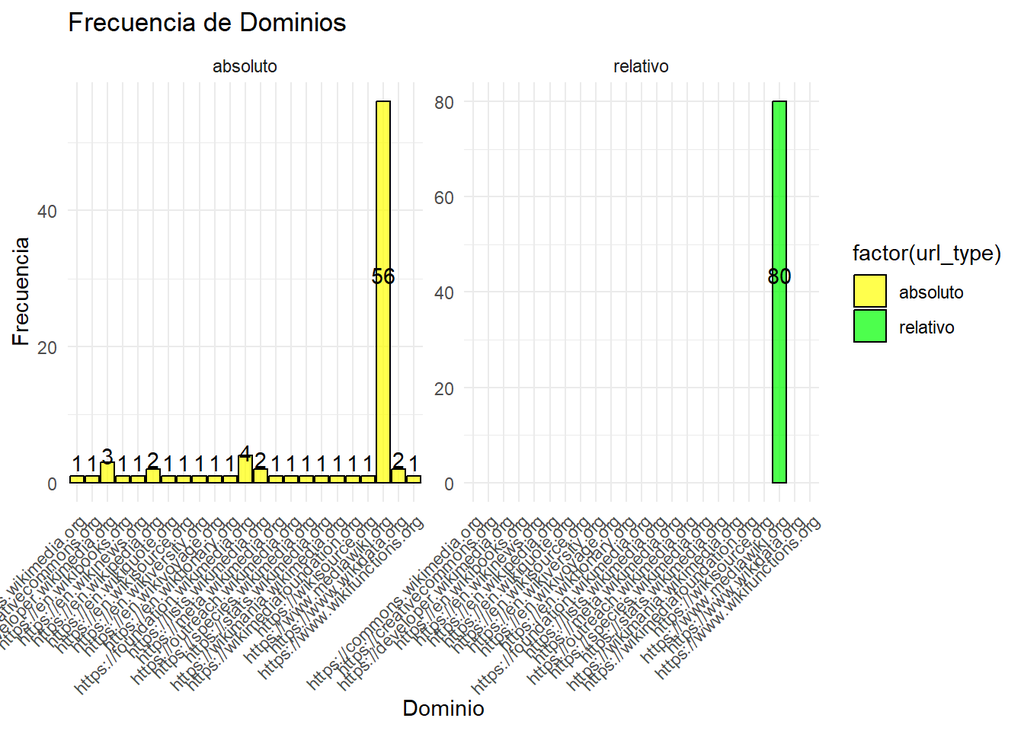

```r
  df3 <- df2 %>%
     mutate(DOMINIO = gsub("^(https?://[^/]+).*", "\\1", HREF))

   df3 <- df3 %>% arrange(desc(cantidad_peticiones))

   ggplot(data = df3, aes(x = DOMINIO, fill = factor(url_type))) +
     geom_bar(color = "black", position = "stack", alpha = 0.7) +
     scale_fill_manual(values = c("yellow", "green")) +
     geom_text(stat = "count", aes(label = ..count..), vjust = -0.5, position = position_stack(vjust = 0.5)) +
     labs(title = "Frecuencia de Dominios", x = "Dominio", y = "Frecuencia") +
     theme_minimal() +
     theme(axis.text.x = element_text(angle = 45, hjust = 1)) +  # Rotar etiquetas en el eje x
     facet_wrap(~url_type, scales = "free_y")  # Facetas por url_type con escalas libres en el eje y
```

## Pregunta 2.2

Un gráfico de barras indicando la suma de enlaces que apuntan a otros dominios o servicios (distinto a https://www.mediawiki.org en el caso de ejemplo) vs. la suma de los otros enlaces

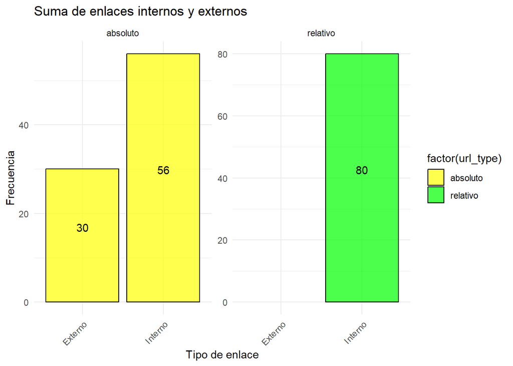

```r
   df3 <- df3 %>%
     mutate(enlace_interno = ifelse(grepl("^https://www.mediawiki.org", DOMINIO), "Interno", "Externo"))

   ggplot(data = df3, aes(x = enlace_interno, fill = factor(url_type))) +
     geom_bar(color = "black", position = "stack", alpha = 0.7) +
     scale_fill_manual(values = c("yellow", "green")) +
     geom_text(stat = "count", aes(label = ..count..), vjust = -0.5, position = position_stack(vjust = 0.5)) +
     labs(title = "Suma de enlaces internos y externos", x = "Tipo de enlace", y = "Frecuencia") +
     theme_minimal() +
     theme(axis.text.x = element_text(angle = 45, hjust = 1)) +
     facet_wrap(~url_type, scales = "free_y")
```

#Pregunta 2.3 Un gráfico de tarta (pie chart) indicando los porcentajes de Status de nuestro análisis

```r
 pie_chart <- PieChart(
     responseCode,
     hole = 0,
     values = "%",
     data = df3,
     fill = c("blue", "red"),
     main = "Porcentajes de Status Code",
     percent_label_color = "black",
     show_legend = FALSE
   )
```

```
## >>> suggestions
## PieChart(responseCode, hole=0)  # traditional pie chart
## PieChart(responseCode, values="%")  # display %'s on the chart
## PieChart(responseCode)  # bar chart
## Plot(responseCode)  # bubble plot
## Plot(responseCode, values="count")  # lollipop plot
##
## --- responseCode ---
##
##                  200    404     Total
## Frequencies:      91     75       166
## Proportions:   0.548  0.452     1.000
##
## Chi-squared test of null hypothesis of equal probabilities
##   Chisq = 1.542, df = 1, p-value = 0.214
```

```r
   legend("topleft", legend = c("200", "404"),
          fill =  c("blue", "red"))
```

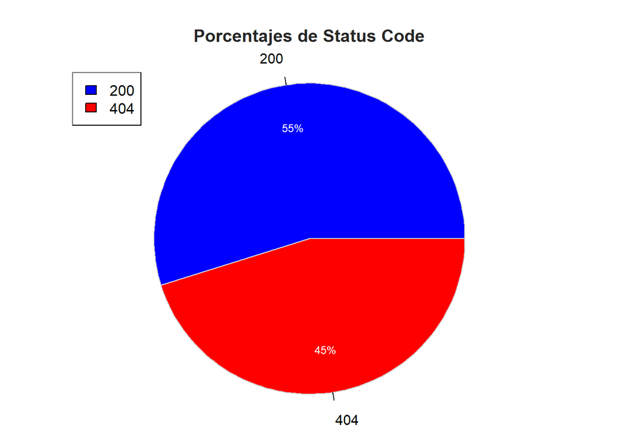